# penguins

kimberly yom

2022-08-02

typing view(penguins) in the console brings up the data frame

```r
#first 6 lines
head(penguins)
```

```
## # A tibble: 6 × 8
##   species island    bill_length_mm bill_depth_mm flipper_l…¹ body_…² sex    year
##   <fct>   <fct>              <dbl>         <dbl>       <int>   <int> <fct> <int>
## 1 Adelie  Torgersen           39.1          18.7         181    3750 male   2007
## 2 Adelie  Torgersen           39.5          17.4         186    3800 fema…  2007
## 3 Adelie  Torgersen           40.3          18           195    3250 fema…  2007
## 4 Adelie  Torgersen           NA            NA            NA      NA <NA>   2007
## 5 Adelie  Torgersen           36.7          19.3         193    3450 fema…  2007
## 6 Adelie  Torgersen           39.3          20.6         190    3650 male   2007
## # … with abbreviated variable names ¹flipper_length_mm, ²body_mass_g
```

```r
#last 6 lines
tail(penguins)
```

```
## # A tibble: 6 × 8
##   species   island bill_length_mm bill_depth_mm flipper_le…¹ body_…² sex    year
##   <fct>     <fct>           <dbl>         <dbl>        <int>   <int> <fct> <int>
## 1 Chinstrap Dream            45.7          17            195    3650 fema…  2009
## 2 Chinstrap Dream            55.8          19.8          207    4000 male   2009
## 3 Chinstrap Dream            43.5          18.1          202    3400 fema…  2009
## 4 Chinstrap Dream            49.6          18.2          193    3775 male   2009
## 5 Chinstrap Dream            50.8          19            210    4100 male   2009
## 6 Chinstrap Dream            50.2          18.7          198    3775 fema…  2009
## # … with abbreviated variable names ¹flipper_length_mm, ²body_mass_g
```

Scatterplot of body mass versus flipper length:

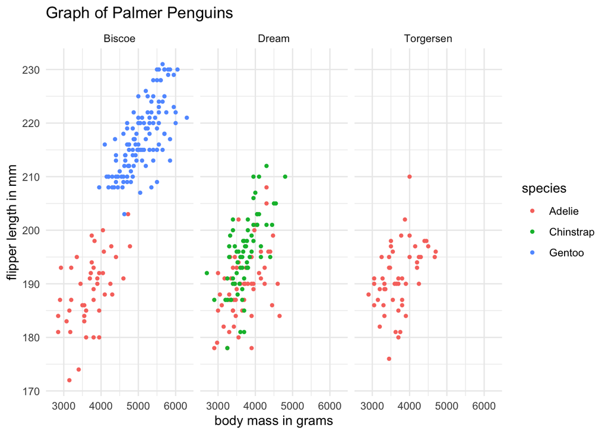

```r
ggplot(data = penguins, aes(x = body_mass_g, y = flipper_length_mm)) + geom_point(aes(color = species), size = 1)  +
  facet_wrap(~island) +
  theme_minimal() +
  labs(
    x = "body mass in grams", y = "flipper length in mm", title = "Graph of Palmer Penguins")
```

```r
#this tells us that the color is dependent on the species
#~ means "as the different functions of island", makes three separate panels for islands
```

anytime you want to change any part of a graph’s aesthetics based on variables, you do it through aes (see previous code chunk). You can put it out of the aes(), but then it’s not dependent on a variable. If it’s referring to a variable it goes in aes() if it’s not referring to a variable it goes outside of aes, ex. ggplot(data = penguins, aes(x = body_mass_g, y = flipper_length_mm)) + geom_point(aes(color = species), size = 4) + facet_wrap(~island)+ theme_minimal() + labs(x = “Body Mass in Grams”, y = “Flipper Length (mm)”, title = “Penguin Graphs”)

will generate a constant dot size of 4 for all penguins, adds panels for the different islands, added a minimal theme, adds labels to the axis and graph title

#### In a new code chunk, create a ggplot graph of penguin bill length versus bill depth (using the penguins dataset in the palmerpenguins package), with point color dependent on species. You should attach the tidyverse and palmerpenguins package in your .Rmd setup chunk. Update labels and add a title.

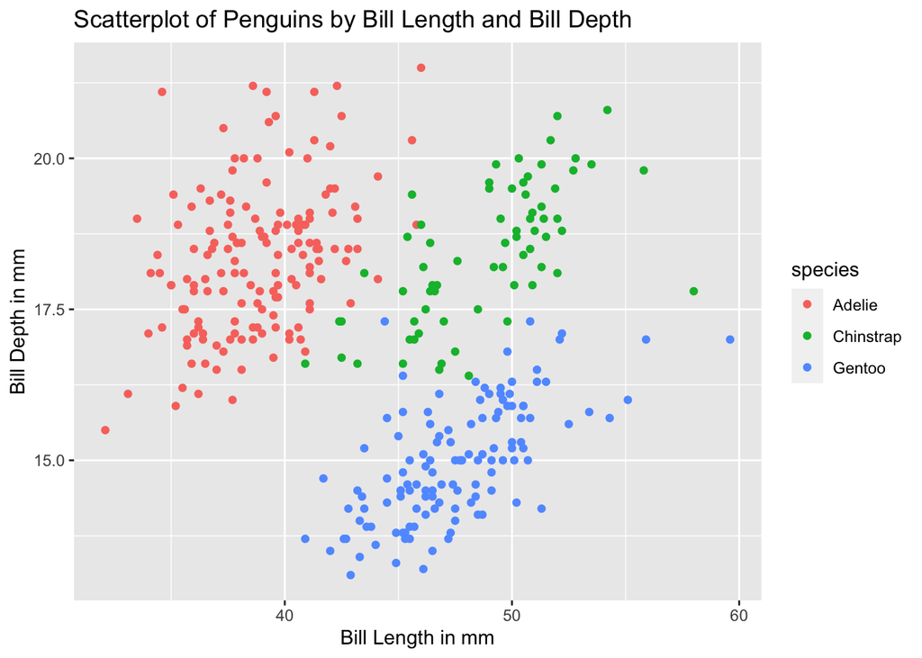

```r
ggplot(data = penguins, aes(x = bill_length_mm, y = bill_depth_mm)) + geom_point(aes(color = species)) +
  labs(x = "Bill Length in mm", y = "Bill Depth in mm", title = "Scatterplot of Penguins by Bill Length and Bill Depth")
```

#### In a new code chunk, make a jitterplot of flipper length by species (species on the x-axis, flipper length on the y-axis). Update axis labels and add a title.

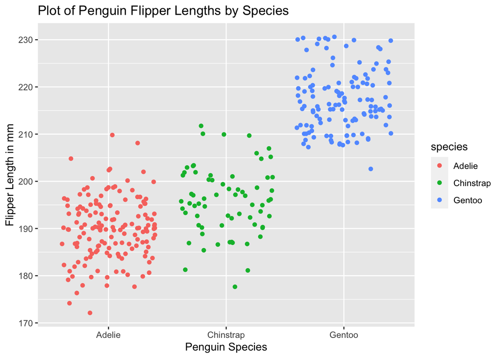

```r
ggplot(data = penguins, aes(x = species, y = flipper_length_mm)) + geom_jitter(aes(color = species))+
  labs(x = "Penguin Species", y = "Flipper Length in mm", title = "Plot of Penguin Flipper Lengths by Species")
```

```r
#geom_jitter is random space between each point, same data as geom_point, but better for aesthetic purposes
```